# Likelihood of a Tree

## Reading And Working With The Data

First, let’s read in the data and see how it is represented. For reading in the tree I’m going to take advantage of the `read.tree()` function from the **ape** package because writing a function for reading in a tree is a pain. If you’re interested in how to write a tree reading function I’d recommend checking out Paul Lewis’ tutorial for [building phylogenetic software](https://stromtutorial.github.io/), it also serves as a good introduction to C++. As for reading in the sequence data, we will be using the `read.nexus.data()` function in **ape**.

```r
##Load in relevant packages
library(ape) ##This package has a lot of tree-related functions and has the 'phylo' class

##Load in prewritten functions
source("./challenge_fxns.R")


##read in our files
tree<-read.tree("../data/challenge_tree.tree")
seq<-read.nexus.data("../data/challenge_data.nex")
```

Cool beans! Now let’s see how the data are represented in R. Let’s start with the tree.

### The Tree

```r
print(tree)##We can see some basic information by just printing our tree
```

```
##
## Phylogenetic tree with 3 tips and 2 internal nodes.
##
## Tip labels:
## [1] "t1" "t2" "t3"
##
## Rooted; includes branch lengths.
```

```r
str(tree)##We can see the attributes and class of our tree by using the str() function
```

```
## List of 4
##  $ edge       : int [1:4, 1:2] 4 5 5 4 5 1 2 3
##  $ edge.length: num [1:4] 0.1 0.1 0.1 0.1
##  $ Nnode      : int 2
##  $ tip.label  : chr [1:3] "t1" "t2" "t3"
##  - attr(*, "class")= chr "phylo"
##  - attr(*, "order")= chr "cladewise"
```

By printing out the tree we can see that we have a rooted tree with 3 tips and branch lengths, this is what we want and a good sanity check.

when we used the `str()` function we could see that the tree was of class *phylo* and had 4 attributes:

- **edge:** This is a matrix that denotes the topology of the tree and how the branches of our tree connect to nodes. Each row of the matrix corresponds to an branch and the two columns correspond to the two nodes for that branch.
- **edge.length:** This is a vector of edge lengths. Each element corresponds to a row in the *edge* matrix. E.g. the 3<sup>rd</sup> element in the *edge.length* attribute corresponds to the branch in the 3<sup>rd</sup> row of the *edge* matrix.
- **Nnode:** The number of internal nodes in the tree. For a root bifurcating tree with $n$ tips we should have $n-1$ nodes so this checks out.
- **tip.label:**A vector of the tip names are stored here. Each element corresponds to the node numbered with that index. E.g. the 2<sup>nd</sup> element in *tip.label* corresponds to the name of the node that is numbered $2$

We can access the indivudal attributes of the tree by typing our variable followed by *$* and then the name of the attribute. For example:

```r
tree$edge
```

```
##      [,1] [,2]
## [1,]    4    5
## [2,]    5    1
## [3,]    5    2
## [4,]    4    3
```

We can also plot our tree along with its branch lengths to check if we loaded things in correctly

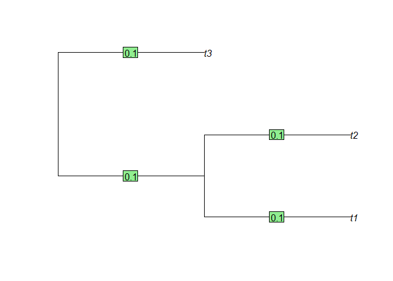

```r
{
  plot(tree)
  edgelabels(tree$edge.length)
}
```

The Newick format for this tree is `((t1:0.1,t2:0.1):0.1,t3:0.1);`, so it looks like the tree is correct.

From the *edge* attribute we can see that nodes and branches are numbered. Alternatively, we can plot the node and edge numberings on the tree.

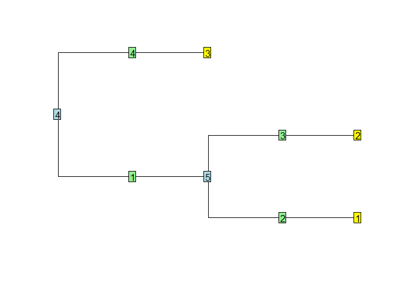

```r
{
  plot(tree,show.tip.label = FALSE)
  edgelabels()
  nodelabels()
  tiplabels()
}
```

We have things plotted such that:

- **Edge Numbers** are denoted with $\color{green}{\text{green}}$
- **Internal Node Numbers** are denoted with $\color{blue}{\text{blue}}$
- **Tip Node Numbers** are denoted with $\color{yellow}{\text{yellow}}$

This plotting is also a good place to make better sense of the *edge* matrix attribute.

```
##      [,1] [,2]
## [1,]    4    5
## [2,]    5    1
## [3,]    5    2
## [4,]    4    3
```

We can see that the second row, denoted by $[2,]$, has $5$ and $1$ in the columns. We can look at our plot and find the branch labeled with a $2$ and see that it is connected to nodes labeled $5$ and $1$.

We can also notice that the ordering the columns matters. Node numbers that appear in the first column of the edge matrix are considered the ancestral node of the branch while node numbers in the second column are considered the descendant node of the branch. We can easily see that $5$ is the ancestor, or parent, node for edge $2$ while node $1$ is the descendent, or child, of the branch. Pretty slick!

### The Sequence Data

Similar things can be done for the sequence data to get a feel for how it is represented.

```r
str(seq)
```

```
## List of 3
##  $ t1: chr "t"
##  $ t2: chr "c"
##  $ t3: chr "a"
```

Here we can see that we have a list where each attribute in the list corresponds to one of our tip names. Then, within each list is our sequence information. Usually each attribute contains a vector of characters, however, we only read in an allignment with one character.